# Homework 9-2 Tree Ensemble Methods Solutions

Nithin Mahesh

### Ensemble Methods with Trees

This file deals with bagging, random forests, and boosting techniques. The first part demonstrates fitting and evaluating a single regression tree on a data set, as done previously. Then ensemble techniques are fit to the same data set and their evaluations compared. In the second part, you are asked to fit ensemble techniques to data sets you have previously analyzed with single trees.

```r
library(tree)
library(randomForest)
library(gbm) # for boosting
```

#### Part 1: Regression analysis on Carseat Sales.

You will compare single and ensemble decision tree methods to predict carseat sales using the “carseat_sales_reg.csv”" data set. It is the same data as the carseat_sales.csv except the Sales column is a numeric value. You will predict the Sales variable using all of the other columns as predictors.

Q1 (5pts): Using the seed value below, create test and train sets that are 50% of the data each. Read in the file “carseat_sales_reg.csv” and remove the SalesLevel column. Also create a variable that is assigned to the true Sales values from the test set.

```r
seed.val<-12345
set.seed(seed.val)
data.df<- read.csv("carseat_sales_reg.csv")
data.size<-nrow(data.df)
train.rows<-sample(1:data.size, data.size/2)
train.data<-data.df[train.rows,]
test.data<-data.df[-train.rows,]
true.vals<-test.data[, 1]
```

#### Single tree models

Q2 (5pts): Fit a tree using the “tree” function on the training data that predicts Sales. Plot the tree with selection criteria and labels. Also print the text representation of the tree to the console.

```r
salesTree<-tree(Sales~., data=train.data)
summary(salesTree)
```

```
##
## Regression tree:
## tree(formula = Sales ~ ., data = train.data)
## Variables actually used in tree construction:
## [1] "SalesLevel" "ShelveLoc"  "Income"     "Education"
## Number of terminal nodes:  6
## Residual mean deviance:  2.254 = 437.3 / 194
## Distribution of residuals:
##     Min.  1st Qu.   Median     Mean  3rd Qu.     Max.
## -4.12900 -1.02600 -0.07754  0.00000  1.00600  3.81100
```

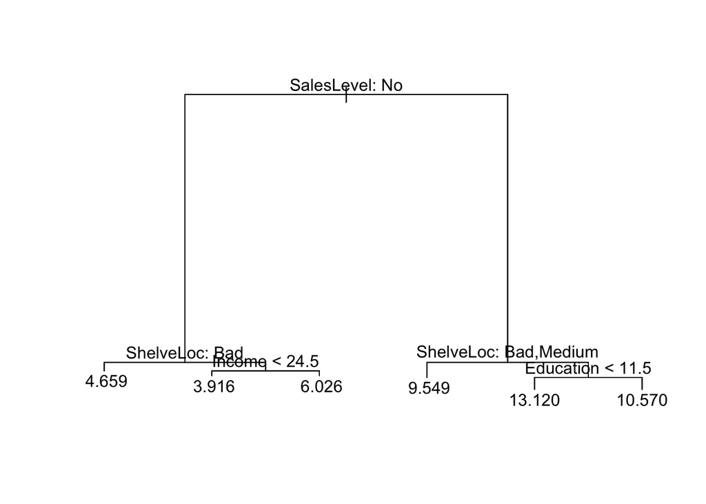

```r
plot(salesTree)
text(salesTree, pretty=0)
```

Q3 (5pts): Now look for a smaller tree size by plotting the deviation vs tree size. Use the seed provided.

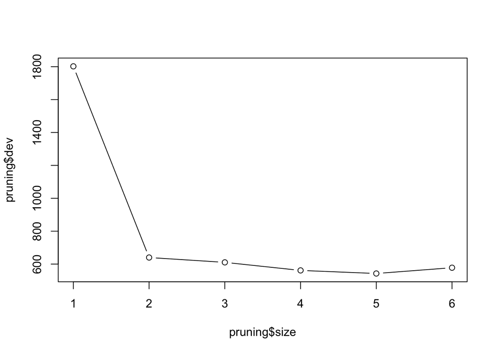

```r
set.seed(seed.val)
pruning<-cv.tree(salesTree)
plot(pruning$size, pruning$dev, type="b")
```

```r
pruning
```

```
## $size
## [1] 6 5 4 3 2 1
##
## $dev
## [1]  578.0253  542.9066  561.6694  610.5984  640.0194 1802.0143
##
## $k
## [1]       -Inf   20.71698   37.02722   51.82557   65.80339 1167.20273
##
## $method
## [1] "deviance"
##
## attr(,"class")
## [1] "prune"         "tree.sequence"
```

Q4 (5pts): Generate a pruned tree by picking the size in the range of [5,10] with the lowest deviance from the plot above. Plot the tree with selection criteria and labels. Also print the text representation of the pruned tree to the console.

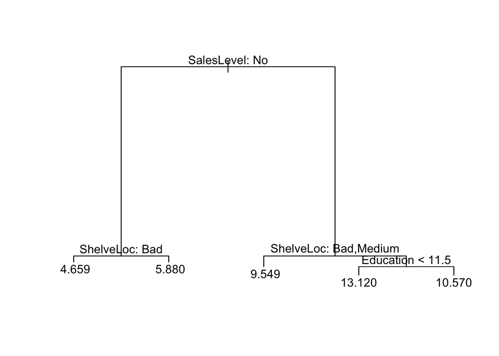

```r
prunedTree<-prune.tree(salesTree, best=5)
plot(prunedTree)
text(prunedTree, pretty=0)
```

What are the most important predictors included in the model?

| # The most important predictors included are SalesLevel, ShelveLoc, and Education. |
| --- |

Q5 (5pts): Now make predictions and calculate mean squared error MSE to evaluate the unpruned and pruned tree models. Summarize the results. Are these expected? Briefly explain.

```r
unprunedPredictions <- predict(salesTree, newdata=test.data)
mean((unprunedPredictions-true.vals)^2)
```

```
## [1] 2.709357
```

```r
prunedPredictions <- predict(prunedTree, newdata=test.data)
mean((prunedPredictions-true.vals)^2)
```

```
## [1] 2.595379
```

[output not shown]